# Lab 04 - La Quinta is Spanish for next to Denny’s, Pt. 1

Sebastian Kaltenbach

10/07/2021

### Load packages and data

```r
library(tidyverse)
library(dsbox)
```

Access and save relevant states in variable “states”

```r
states <- read_csv("data/states.csv")
```

### Exercise 1

What are the dimensions of the Denny’s dataset? (Hint: Use inline R code and functions like nrow and ncol to compose your answer.) What does each row in the dataset represent? What are the variables?

```r
# number of rows
nrow(dennys)
```

```
[1] 1643
```

```r
# number of columns
ncol(dennys)
```

```
[1] 6
```

```r
# Header definition
names(dennys)
```

```
[1] "address"   "city"      "state"     "zip"       "longitude" "latitude"
```

Each row contains specific information of a dennys diner location.

### Exercise 2

What are the dimensions of the La Quinta’s dataset? What does each row in the dataset represent? What are the variables?

```r
# number of rows
nrow(laquinta)
```

```
[1] 909
```

```r
# number of columns
ncol(laquinta)
```

```
[1] 6
```

```r
# Header definition
names(laquinta)
```

```
[1] "address"   "city"      "state"     "zip"       "longitude" "latitude"
```

Each row contains specific information of a laquinta hotel location.

### Exercise 3

Take a look at the websites that the data come from (linked above). Are there any La Quinta’s locations outside of the US? If so, which countries? What about Denny’s?

According to the homapage, dennys is a pure american diner chain. In comparison. laquinta hotels are also available in e.g., Europe and therefore internationally relevant.

```r
countries <- c("New Zealand", "Honduras", "Turkey", "United Arab Emirates", "Chile", "Columbia", "Canada")
```

### Exercise 4

Now take a look at the data. What would be some ways of determining whether or not either establishment has any locations outside the US using just the data (and not the websites). Don’t worry about whether you know how to implement this, just brainstorm some ideas. Write down at least one as your answer, but you’re welcomed to write down a few options too.

If there is a variable which can determine, if a location is in the UNited states or not could solve the problem with a simple filter function. This could be by state, or even by longitude latitude. This would include additional analysis if a location (long|lat) is in the U.S. or not.

### Exercise 5

Find the Denny’s locations that are outside the US, if any. To do so, filter the Denny’s locations for observations where state is not in states$abbreviation. The code for this is given below. Note that the %in% operator matches the states listed in the state variable to those listed in states$abbreviation. The ! operator means not. Are there any Denny’s locations outside the US?

```r
dennys_outside_us <- dennys %>% filter(!(state %in% states$abbreviation))
```

There are not dennys locations outside of the U.S.

### Exercise 6

Add a country variable to the Denny’s dataset and set all observations equal to “United States”. Remember, you can use the mutate function for adding a variable. Make sure to save the result of this as dennys again so that the stored data frame contains the new variable going forward.

```r
dennys <- dennys %>% mutate(country = "United States")
```

### Exercise 7

Find the La Quinta locations that are outside the US, and figure out which country they are in. This might require some googling. Take notes, you will need to use this information in the next exercise.

```r
laquinta_outside_us <- laquinta %>% filter(!(state %in% states$abbreviation))
laquinta_countries <- c("Mexico", "Colombia", "Canada", "Honduras")
```

### Exercise 8

Add a country variable to the La Quinta dataset. Use the case_when function to populate this variable. You’ll need to refer to your notes from Exercise 7 about which country the non-US locations are in. Here is some starter code to get you going:

```r
laquinta <- laquinta %>%
  mutate(country = case_when(
    state %in% state.abb ~ "United States",
    state %in% c("ON", "BC") ~ "Canada",
    state == "ANT" ~ "Columbia",
    state == "FM" ~ "Honduras",
    state %in% c("AG", "CH", "NL", "PU", "QR", "SL", "VE") ~ "Mexico"
  ))
```

```r
laquinta <- laquinta %>%
  filter(country == "United States")
```

### Exercise 9

Which states have the most and fewest Denny’s locations? What about La Quinta? Is this surprising? Why or why not?

```r
dennys_states_rank <- dennys %>% count(state) %>% arrange(desc(n))
laquinta_states_rank <- laquinta %>% count(state) %>% arrange(desc(n))
```

dennys top three are: California (403), Texas (200), Florida (140) dennys last three are: District of Columbia (2), Vermont (2), Delaware (1)

laquintas top three are: Texas (237), Florida (74), California (56) laquintas last three are: South Dakota (2), Vermont(2), Maine (1)

Interesting in my opinion is texas, which is available in both top three lists, as well as the close similarity of both lists (except the order).

### Exercise 10

Which states have the most Denny’s locations per thousand square miles? What about La Quinta?

```r
dennys %>%
  count(state) %>%
  inner_join(states, by = c("state" = "abbreviation")) %>%
  mutate(tot_per_thousand_sqr_miles = n / (area / 1000)) %>%
  arrange(desc(tot_per_thousand_sqr_miles))
```

| state | n | name | area | tot_per_thousand_sqr_miles |
| --- | --- | --- | --- | --- |
| DC | 2 | District of Columbia | 68.34 | 29.265437518 |
| RI | 5 | Rhode Island | 1544.89 | 3.236476383 |
| CA | 403 | California | 163694.74 | 2.461899509 |
| CT | 12 | Connecticut | 5543.41 | 2.164732538 |
| FL | 140 | Florida | 65757.70 | 2.129028235 |
| MD | 26 | Maryland | 12405.93 | 2.095771941 |
| NJ | 10 | New Jersey | 8722.58 | 1.146449789 |
| NY | 56 | New York | 54554.98 | 1.026487408 |
| IN | 37 | Indiana | 36419.55 | 1.015937869 |
| OH | 44 | Ohio | 44825.58 | 0.981582391 |

[output cut: 41 more lines]

```r
laquinta %>%
  count(state) %>%
  inner_join(states, by = c("state" = "abbreviation")) %>%
  mutate(tot_per_thousand_sqr_miles = n / (area / 1000)) %>%
  arrange(desc(tot_per_thousand_sqr_miles))
```

| state | n | name | area | tot_per_thousand_sqr_miles |
| --- | --- | --- | --- | --- |
| RI | 2 | Rhode Island | 1544.89 | 1.294590553 |
| FL | 74 | Florida | 65757.70 | 1.125343496 |
| CT | 6 | Connecticut | 5543.41 | 1.082366269 |
| MD | 13 | Maryland | 12405.93 | 1.047885971 |
| TX | 237 | Texas | 268596.46 | 0.882364570 |
| TN | 30 | Tennessee | 42144.25 | 0.711840880 |
| GA | 41 | Georgia | 59425.15 | 0.689943568 |
| NJ | 5 | New Jersey | 8722.58 | 0.573224894 |
| MA | 6 | Massachusetts | 10554.39 | 0.568483825 |
| LA | 28 | Louisiana | 52378.13 | 0.534574258 |

[output cut: 38 more lines]

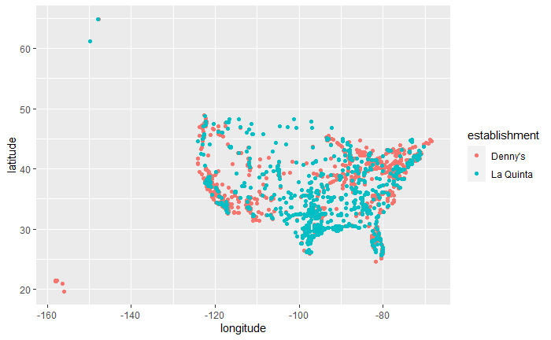

```r
dennys <- dennys %>%
  mutate(establishment = "Denny's")

laquinta <- laquinta %>%
  mutate(establishment = "La Quinta")

dn_lq <- bind_rows(dennys, laquinta)

ggplot(dn_lq, mapping = aes(x = longitude, y = latitude, color = establishment)) +
  geom_point()
```

### Exercise 11

Filter the data for observations in North Carolina only, and recreate the plot. You should also adjust the transparency of the points, by setting the alpha level, so that it’s easier to see the overplotted ones. Visually, does Mitch Hedberg’s joke appear to hold here?

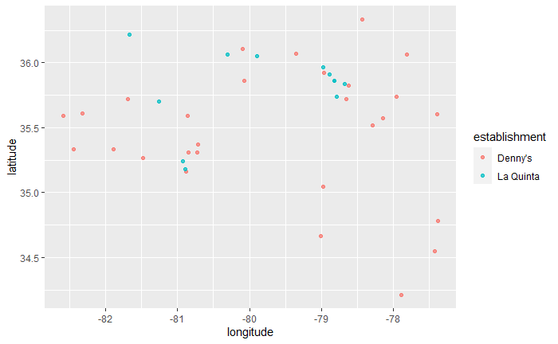

```r
dn_carolina <- dn_lq %>% filter(state == "NC")

ggplot(dn_carolina, mapping = aes(x = longitude, y = latitude, color = establishment)) +
  geom_point(alpha = 0.75)
```

According to the plot, the joke seems to be not working!

### Exercise 12

Now filter the data for observations in Texas only, and recreate the plot, with an appropriate alpha level. Visually, does Mitch Hedberg’s joke appear to hold here?

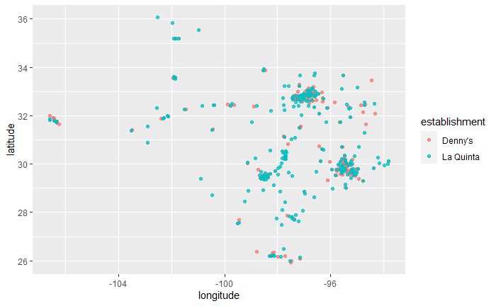

```r
dn_texas <- dn_lq %>% filter(state == "TX")

ggplot(dn_texas, mapping = aes(x = longitude, y = latitude, color = establishment)) +
  geom_point(alpha = 0.75)
```

According to the plot, the joke seems to be working!